# Simulation and profiling

Jorge A. Garza-Venegas

29/7/2022

## The `str` function

This function is used to display compactly the internal **structure** of an R object.

```r
str(str)
```

```
## function (object, ...)
```

```r
str(lm)
```

```
## function (formula, data, subset, weights, na.action, method = "qr", model = TRUE,
##     x = FALSE, y = FALSE, qr = TRUE, singular.ok = TRUE, contrasts = NULL,
##     offset, ...)
```

```r
x <- rnorm(100,0,2)
summary(x)
```

```
##    Min. 1st Qu.  Median    Mean 3rd Qu.    Max.
## -4.3867 -1.4541 -0.2395 -0.1373  1.1140  5.0651
```

```r
str(x)
```

```
##  num [1:100] 3.2729 -0.4909 1.5196 1.5149 -0.0528 ...
```

```r
f <- gl(40,10)
str(f)
```

```
##  Factor w/ 40 levels "1","2","3","4",..: 1 1 1 1 1 1 1 1 1 1 ...
```

We can use this function with data frames to check the types of their column variables.

```r
head(airquality)
```

```
##   Ozone Solar.R Wind Temp Month Day
## 1    41     190  7.4   67     5   1
## 2    36     118  8.0   72     5   2
## 3    12     149 12.6   74     5   3
## 4    18     313 11.5   62     5   4
## 5    NA      NA 14.3   56     5   5
## 6    28      NA 14.9   66     5   6
```

```r
str(airquality)
```

```
## 'data.frame':    153 obs. of  6 variables:
##  $ Ozone  : int  41 36 12 18 NA 28 23 19 8 NA ...
##  $ Solar.R: int  190 118 149 313 NA NA 299 99 19 194 ...
##  $ Wind   : num  7.4 8 12.6 11.5 14.3 14.9 8.6 13.8 20.1 8.6 ...
##  $ Temp   : int  67 72 74 62 56 66 65 59 61 69 ...
##  $ Month  : int  5 5 5 5 5 5 5 5 5 5 ...
##  $ Day    : int  1 2 3 4 5 6 7 8 9 10 ...
```

```r
s <- split(airquality, airquality$Month)
summary(s)
```

```
##   Length Class      Mode
## 5 6      data.frame list
## 6 6      data.frame list
## 7 6      data.frame list
## 8 6      data.frame list
## 9 6      data.frame list
```

```r
str(s)
```

```
## List of 5
##  $ 5:'data.frame':   31 obs. of  6 variables:
##   ..$ Ozone  : int [1:31] 41 36 12 18 NA 28 23 19 8 NA ...
##   ..$ Solar.R: int [1:31] 190 118 149 313 NA NA 299 99 19 194 ...
##   ..$ Wind   : num [1:31] 7.4 8 12.6 11.5 14.3 14.9 8.6 13.8 20.1 8.6 ...
##   ..$ Temp   : int [1:31] 67 72 74 62 56 66 65 59 61 69 ...
##   ..$ Month  : int [1:31] 5 5 5 5 5 5 5 5 5 5 ...
##   ..$ Day    : int [1:31] 1 2 3 4 5 6 7 8 9 10 ...
##  $ 6:'data.frame':   30 obs. of  6 variables:
##   ..$ Ozone  : int [1:30] NA NA NA NA NA NA 29 NA 71 39 ...
##   ..$ Solar.R: int [1:30] 286 287 242 186 220 264 127 273 291 323 ...
##   ..$ Wind   : num [1:30] 8.6 9.7 16.1 9.2 8.6 14.3 9.7 6.9 13.8 11.5 ...
##   ..$ Temp   : int [1:30] 78 74 67 84 85 79 82 87 90 87 ...
##   ..$ Month  : int [1:30] 6 6 6 6 6 6 6 6 6 6 ...
##   ..$ Day    : int [1:30] 1 2 3 4 5 6 7 8 9 10 ...
##  $ 7:'data.frame':   31 obs. of  6 variables:
##   ..$ Ozone  : int [1:31] 135 49 32 NA 64 40 77 97 97 85 ...
##   ..$ Solar.R: int [1:31] 269 248 236 101 175 314 276 267 272 175 ...
##   ..$ Wind   : num [1:31] 4.1 9.2 9.2 10.9 4.6 10.9 5.1 6.3 5.7 7.4 ...
##   ..$ Temp   : int [1:31] 84 85 81 84 83 83 88 92 92 89 ...
##   ..$ Month  : int [1:31] 7 7 7 7 7 7 7 7 7 7 ...
##   ..$ Day    : int [1:31] 1 2 3 4 5 6 7 8 9 10 ...
##  $ 8:'data.frame':   31 obs. of  6 variables:
##   ..$ Ozone  : int [1:31] 39 9 16 78 35 66 122 89 110 NA ...
##   ..$ Solar.R: int [1:31] 83 24 77 NA NA NA 255 229 207 222 ...
##   ..$ Wind   : num [1:31] 6.9 13.8 7.4 6.9 7.4 4.6 4 10.3 8 8.6 ...
##   ..$ Temp   : int [1:31] 81 81 82 86 85 87 89 90 90 92 ...
##   ..$ Month  : int [1:31] 8 8 8 8 8 8 8 8 8 8 ...
##   ..$ Day    : int [1:31] 1 2 3 4 5 6 7 8 9 10 ...
##  $ 9:'data.frame':   30 obs. of  6 variables:
##   ..$ Ozone  : int [1:30] 96 78 73 91 47 32 20 23 21 24 ...
##   ..$ Solar.R: int [1:30] 167 197 183 189 95 92 252 220 230 259 ...
##   ..$ Wind   : num [1:30] 6.9 5.1 2.8 4.6 7.4 15.5 10.9 10.3 10.9 9.7 ...
##   ..$ Temp   : int [1:30] 91 92 93 93 87 84 80 78 75 73 ...
##   ..$ Month  : int [1:30] 9 9 9 9 9 9 9 9 9 9 ...
##   ..$ Day    : int [1:30] 1 2 3 4 5 6 7 8 9 10 ...
```

## Simulation - Generating random numbers.

There are several functions in R to generate random variables, following the structure

$$\textit{prefix} + \textit{suffix}$$
where **prefix** can be one of the following letters:

- **d** for density.
- **r** for random number generation.
- **p** for cumulative distribution.
- **q** for quantile function.

and **suffix** is a distribution name. Some examples are

| suffix | Distribution Name |
| --- | --- |
| binom | Binomial distribution |
| geom | Geometric distribution |
| pois | Poisson distribution |
| norm | Normal distribution |
| exp | Exponential distribution |
| gamma | Gamma distribution |
| weibull | Weibull distribution |
| t | t Distribution |
| f | F distribution |
| chisq | chi-squared distribution |

Let’s take a look at some examples

```r
# Simulating random normal variables.
x <- rnorm(10)
x
```

```
##  [1]  1.022031576  0.755937422  0.524333577  0.201697174  0.807380319
##  [6] -0.520245153 -0.006655334 -0.823485741 -1.326369078 -0.420174946
```

```r
y<- rnorm(n = 10, mean = 20, sd = 2)
y
```

```
##  [1] 21.19435 18.58567 21.93577 19.20223 22.25431 20.48520 15.76962 19.27268
##  [9] 17.20948 17.11365
```

```r
summary(y)
```

```
##    Min. 1st Qu.  Median    Mean 3rd Qu.    Max.
##   15.77   17.55   19.24   19.30   21.02   22.25
```

Setting a random number seed **ensures reproducibility**. In R, this can be done with the function `set.seed()`

```r
rnorm(5)
```

```
## [1] -0.58585364 -0.91503641 -0.98542842 -0.01352934 -2.12790095
```

```r
rnorm(5)
```

```
## [1] -1.7057647  0.3382020  1.6635096  0.2294357  0.4287934
```

```r
set.seed(1)
rnorm(5)
```

```
## [1] -0.6264538  0.1836433 -0.8356286  1.5952808  0.3295078
```

```r
set.seed(1)
rnorm(5)
```

```
## [1] -0.6264538  0.1836433 -0.8356286  1.5952808  0.3295078
```

```r
rnorm(5)
```

```
## [1] -0.8204684  0.4874291  0.7383247  0.5757814 -0.3053884
```

```r
# Exponential distribution
rexp(n = 10, rate = 1)
```

```
##  [1] 0.1470460 1.3907351 0.7620299 1.2376036 4.4239342 1.0545432 1.0352439
##  [8] 1.8760352 0.6547466 0.3369335
```

```r
# P(X <=1)
pexp(q = 1, rate = 1)
```

```
## [1] 0.6321206
```

```r
# Binomial distribution
rbinom(n = 2, size = 10, prob = 0.5)
```

```
## [1] 6 3
```

```r
# P(X < 5)
qbinom(0.5, size = 10, prob = 0.5)
```

```
## [1] 5
```

```r
qbinom(0.6230469, size = 10, prob = 0.5)
```

```
## [1] 6
```

```r
pbinom(6,10,0.5) - pbinom(5,10,0.5)
```

```
## [1] 0.2050781
```

```r
dbinom(6,10,0.5)
```

```
## [1] 0.2050781
```

## Simulation - Simulating a linear model

In order to model the linear model given by

$$y = \beta_0 + \beta_1x + \varepsilon$$
where $\varepsilon \sim \mathcal{N}\left(0,\sigma^2\right)$ and assuming $\beta_0 = 0.5$ and $\beta_1 = 5$.

```r
beta_0 <- 0.5
beta_1 <- 5
set.seed(20)
x <- rnorm(100)
e <- rnorm(100,0,2)
y <- beta_0 + beta_1*x + e
summary(y)
```

```
##     Min.  1st Qu.   Median     Mean  3rd Qu.     Max.
## -14.1686  -3.2057   0.8637   0.7040   4.6929  12.9014
```

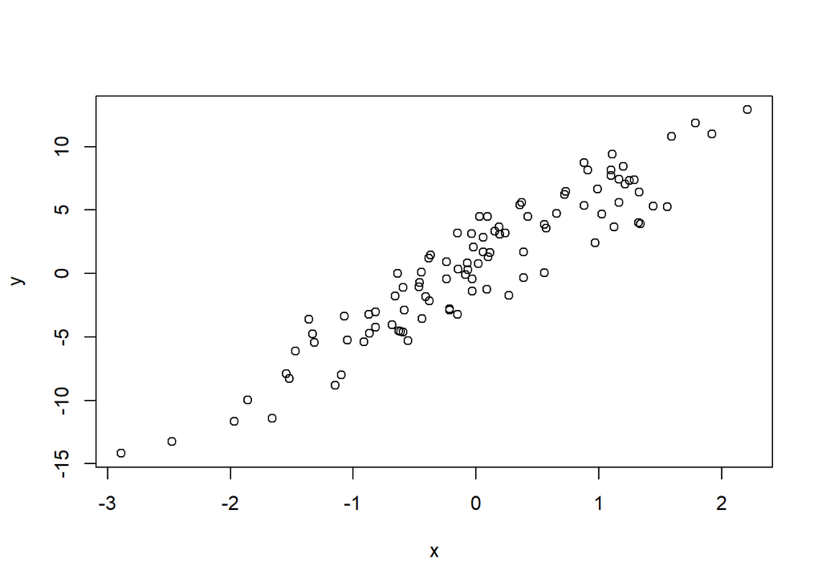

```r
plot(x,y)
```

Generate binary data using a Binomial Distribution.

```r
beta_0 <- 0.5
beta_1 <- 5
set.seed(20)
x <- rbinom(100, 1,0.5)
e <- rnorm(100,0,2)
y <- beta_0 + beta_1*x + e
summary(y)
```

```
##     Min.  1st Qu.   Median     Mean  3rd Qu.     Max.
## -3.43605 -0.03689  2.58556  2.86228  5.62946  9.91689
```

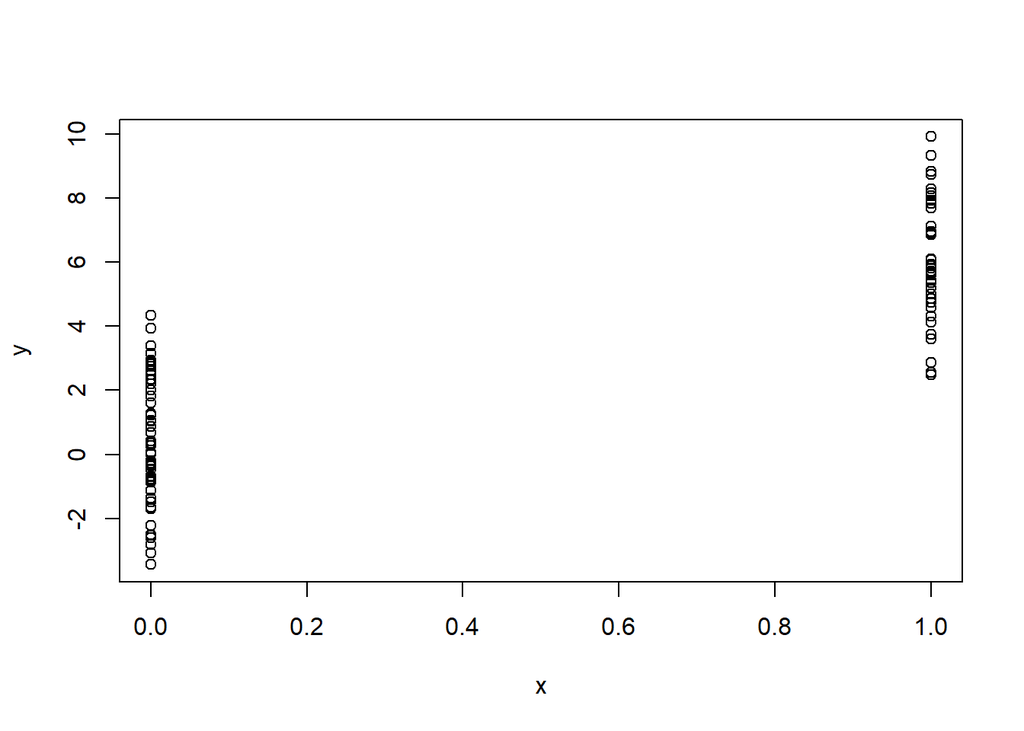

```r
plot(x,y)
```

Another example. Assume that $Y \sim Poisson\left(\mu\right)$ and that $\log\left(\mu\right) = \beta_0 + \beta_1 x$ with $\beta_0 = 0.5$ and $\beta_1 = 0.3$.

```r
set.seed(1)
beta_0 <- 0.5
beta_1 <- 0.3
x <-rnorm(100)
log.mu <- beta_0 + beta_1*x
y <- rpois(n = 100, exp(log.mu))
summary(y)
```

```
##    Min. 1st Qu.  Median    Mean 3rd Qu.    Max.
##    0.00    1.00    1.00    1.55    2.00    6.00
```

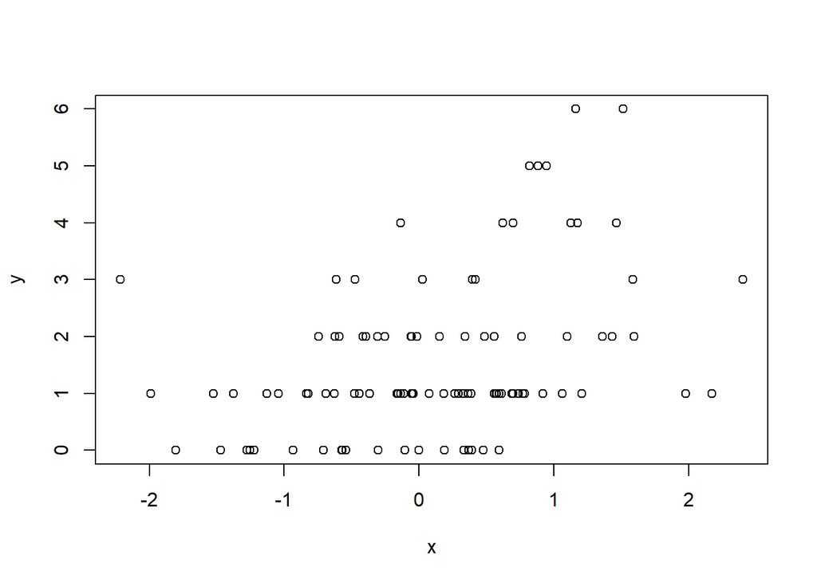

```r
plot(x,y)
```

## Simulation - Random Sampling

One useful function is the `sample` function.

```r
set.seed(1)
sample(1:10,4)
```

```
## [1] 9 4 7 1
```

```r
sample(1:10,4)
```

```
## [1] 2 7 3 6
```

```r
sample(letters,5)
```

```
## [1] "r" "s" "a" "u" "w"
```

```r
sample(1:10)  # This is a permutation.
```

```
##  [1] 10  6  9  2  1  5  8  4  3  7
```

```r
sample(1:10, replace = TRUE)
```

```
##  [1]  5  5  2 10  9  1  4  3  6 10
```

## R Profiler (Part 1)

**Profiling** is a systematic way to examine how much time is spend in different parts of a program and it is very useful for code optimization.

General principles of optimization

- Design, first, then optimize.
- “Premature optimization is the root of all evil” Donald Knuth.
- Measure (collect data), do not guess.

### The `system.time()` function

This function computes the time (in seconds) needed to execute an expression as it can be seen in the following examples.

```r
system.time(rnorm(100))
```

```
##    user  system elapsed
##       0       0       0
```

```r
system.time(rnorm(100000000))
```

```
##    user  system elapsed
##    5.87    0.03    6.00
```

where **user** is the time charged to the CPU(s) for this expression and **elapsed** is the time experienced by the user and sometimes called “wall clock” time. **Elapsed** might be smaller than **user** when your computer has multiple processors and is capable of use them. (One way to use them is via the **parallel** package)

```r
system.time(readLines("http://www.jhsph.edu"))
```

```
##    user  system elapsed
##    0.10    0.10    1.56
```

```r
hilbert <- function(n){
    i <- 1:n
    1/outer(i-1,i,"+")
}
x <- hilbert(1000)
system.time(svd(x))
```

```
##    user  system elapsed
##    2.56    0.00    2.63
```

Longer expression can be timed using curly braces.

```r
system.time({
    n <- 100
    r <- numeric(n)
    for (i in 1:n) {
        x <-rnorm(n)
        r[i] <- mean(x)
    }
})
```

```
##    user  system elapsed
##    0.02    0.00    0.02
```

This is useful when you now where the problem is, or at least have an idea where to check.

## R Profiler (Part 2)

The profiler in R is started with the `RProf()` function. It keeps track of the function call stack at regularly sampled intervals (default is 0.02 secs) and tabulates how much time is spend in each function.

The output of this function is usually “not readable”, so that the `summaryRProf()` might be used.

You have to note that C or Fortran code are not profiled.